# LinReg_slidy

Philipp Mildenberger

16 März 2020

$$\newcommand\xbar{\overline{x}}
\def\ybar{\overline{y}}
\def\eps{\epsilon}$$

# Chapter Overview

- Motivating Example
- Simple Linear Regression
- Multiple Linear Regression
- Other Considerations in the Regression Model
- Example expained
- Comparison to $K$-Nearest Neighbors

# Motivating Example

## Advertising Data

| X | TV | radio | newspaper | sales |
| --- | --- | --- | --- | --- |
| 1 | 230.1 | 37.8 | 69.2 | 22.1 |
| 2 | 44.5 | 39.3 | 45.1 | 10.4 |
| 3 | 17.2 | 45.9 | 69.3 | 9.3 |
| 4 | 151.5 | 41.3 | 58.5 | 18.5 |
| 5 | 180.8 | 10.8 | 58.4 | 12.9 |
| 6 | 8.7 | 48.9 | 75 | 7.2 |

# Motivating Example

## Questions

- Is there a relationship between advertising budget and sales?
- How strong is the relationship between advertising budget and sales?
- Which media contribute to sales?
- How accurately (and precisely) can we estimate the effect of each medium?
- How accurately can we predict future sales?
- Is the relationship linear?
- Is there synergy (i.e. interaction) among the advertising media?

# Simple Linear Regression

Predict quantitative response $Y$ on the basis of $X$

$$Y \approx \beta_0 + \beta_1 X$$

- $\beta_0$ is called “Intercept” and $\beta_1$ “slope”. Both are often called “coefficients” “parameters”
- Both are unknown, will be estimated

With estimates $\hat\beta_0$ , $\hat\beta_1$, one can then make predictions for $Y$ based on observed values of $X$:

$$\hat y = \hat \beta_0 + \hat\beta_1 x$$

# Estimating the Coefficients $\beta_0$ and $\beta_1$

- Let $y_i:=\hat \beta_0 + \hat\beta_1 x_i$ be the prediction for $Y$ based on the $i$-th value of $X$.
- The residual sum of squares (RSS) is defined as

$$\text{RSS}:= (y_1 - \hat y_1)^2 + \ldots + (y_n - \hat y_n)^2$$

- We want to minimise the RSS (“Least Squares”).  
  Letting $\frac{d\text{RSS}}{d\beta} \stackrel{!}= 0$ yields

$$\begin{aligned}
\hat \beta_1 =& \frac{\sum_{i=1}^n(x_i-\xbar)(y_i - \ybar)}
{\sum_{i=1}^n(x_i-\xbar)^2} \\
\hat \beta_0 =& \ybar - \hat \beta_1 \cdot \xbar
\end{aligned}$$

with $\ybar:=\frac{1}{n}\sum_{i=1}^n y_i$ and $\xbar:=\frac{1}{n}\sum_{i=1}^n x_i$ the sample means. These are direct (i.e. non-iterative) calculations :)

# Advertising Example

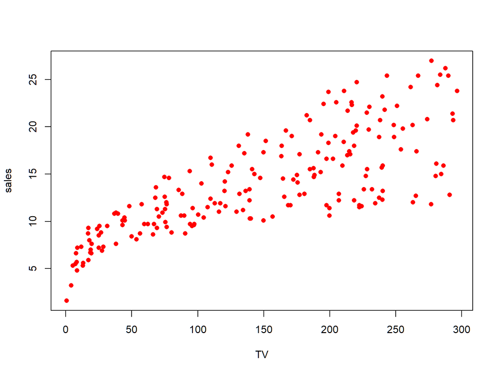

- Scatterplot of `sales` and `TV`

# Advertising Example

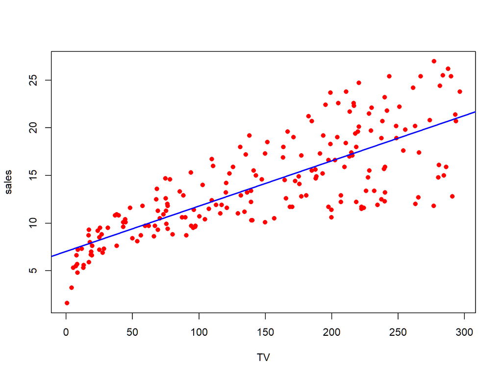

- Scatterplot of `sales` and `TV`
- Best linear fit to the data

# Advertising Example

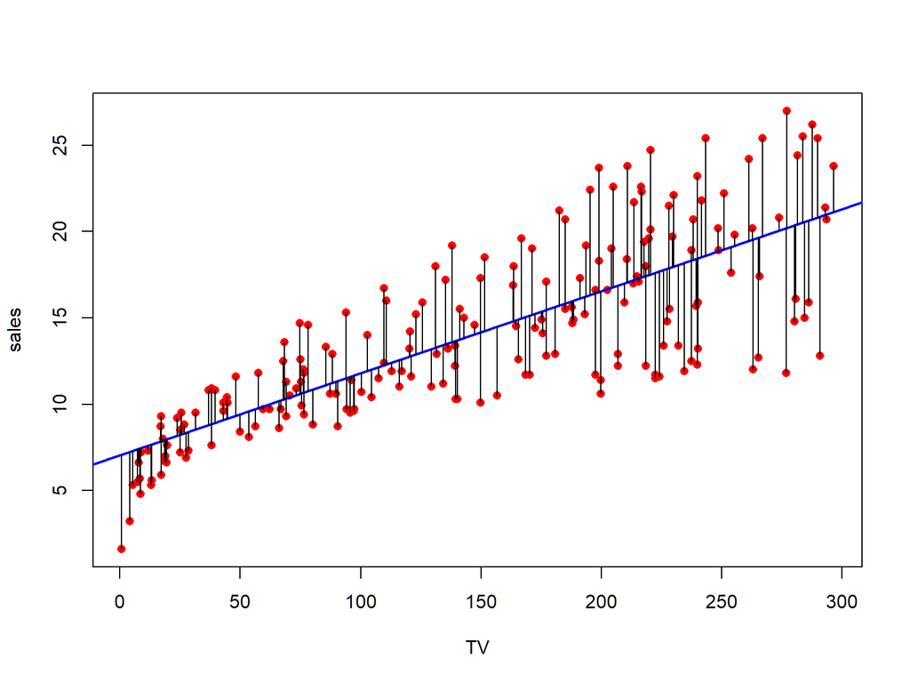

- Scatterplot of `sales` and `TV`
- Best linear fit to the data
- Residuals of the linear regression model

# Advertising Example

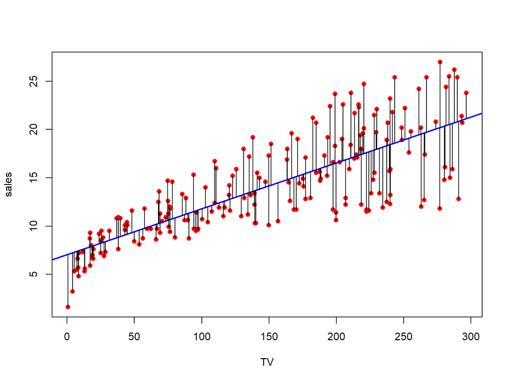

```r
lm(sales~TV, data=Advertising)
```

```
##
## Call:
## lm(formula = sales ~ TV, data = Advertising)
##
## Coefficients:
## (Intercept)           TV
##     7.03259      0.04754
```

# Assessing Accuracy of Coefficient Estimates

We want to know how much randomness went into a particular estimate produced by the estimator $\hat\beta_1$. The standard error quantifies that:

$$\text{SE}(\hat\beta_1)^2=\frac{\sigma^2}{\sum_{i=1}^n(x_i-\xbar)^2} \qquad
\text{SE}(\hat\beta_0)^2=\sigma^2\left[\frac 1 n + \frac{\xbar^2}{\sum_{i=1}^n(x_i-\xbar)^2}\right]$$
where $\sigma^2:=\text{Var}(\eps)$ is the variance of the the random error term.

- We observe
  - Higher $\sigma^2$ leads to larger SE
  - Higher Variance in $X$ leads to smaller SE
- $\sigma^2$ is unknown, but can be estimated with the residuals by

$$\hat\sigma^2:=\frac{RSS}{(n-2)}=\frac{\sum_{i=1}^n(y_i-\hat y_i)^2}{(n-2)}.$$

- The $-2$ in the denominator comes from the two degrees of freedom of the linear model.
  - standard error increases with number of predictors
- By replacing $\sigma^2$ with $\hat \sigma^2$ in the formulae above, we get an estimator $\widehat{\text{SE}}(\hat\beta_1)$ for $\text{SE}(\hat\beta_1)$. This estimator can then be used for the construction of *confidence intervals* or for *hypothesis testing*.

# Example to Accuracy Assessment

Assume the the true model has the form
$$Y = 2 + 3\cdot X + \eps \qquad \eps \stackrel{i.i.d.}{\sim}N(0,4^2)$$

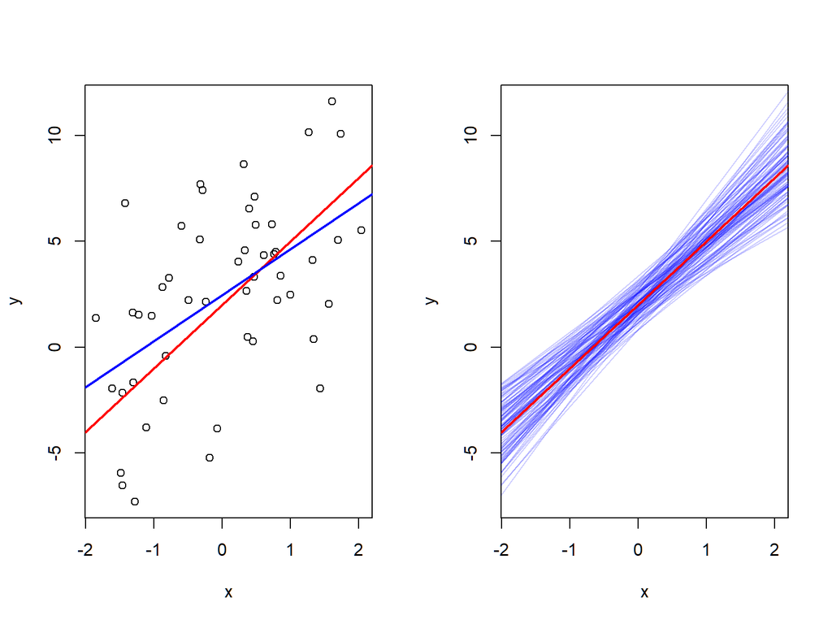

Left: sample of 50 observations. True regression line in red, sample based regression line in blue.  
Right: sample-based regression lines of 100 different samples

The estimated standard error of $\hat\beta_1$ is in this case:

$$\begin{aligned}
\hat\sigma^2 =& \frac{RSS}{n-2} \approx \frac{679.2}{48}= 14.15 \\
\widehat{SE}(\hat\beta_1) =& \sqrt{\frac{RSS}{\sum_{i=1}^n(x_i-\xbar)^2}}
\approx \sqrt{\frac{14.15}{55.7}} \approx 0.504
\end{aligned}$$

… which is the same as r shows us:

```r
pander::pander(lm0)
```

Fitting linear model: y ~ x

|  | Estimate | Std. Error | t value | Pr(>\|t\|) |
| --- | --- | --- | --- | --- |
| **(Intercept)** | 2.458 | 0.5321 | 4.62 | 2.898e-05 |
| **x** | 2.168 | 0.5041 | 4.3 | 8.327e-05 |

We saw above, that the estimate for $\sigma=\sqrt{14.15}\approx 3.76$ was a bit lower than the actual value of $4$. If we look at the 100 different samples, we get 100 estimates that vary around the true value. Their overall mean is 4.01108.  
That means: $\hat\sigma$ estimates $\sigma$ without bias.

# Hypothesis Testing

Standard error can be used to conduct *hypothesis tests* on the coefficients. Often, one wants to assess wheter there is an relationship between $X$ and $Y$, this is the same as testing whether the slope is equal to zero.

- **$H_0$**: $\beta_1=0$ i.e. there is no relationship between $X$ and $Y$
- **$H_A$**: $\beta_1\neq0$ i.e. there is some relationship between $X$ and $Y$

Under the assumption that the null hypothesis is true, we get a *t-statistic* with $n-2$ degrees of freedom.
$$t=\frac{\hat\beta_1 - 0}{\widehat{\text{SE}}(\hat\beta_1)} \qquad$$
This is $t$-distributed since we needed to estimate the standard error.

# Assessing the Accuracy of the Model

**Residual Standard Error (RSE)**

The RSE is an estimate of the standard deviation of the random error $\eps$. It is the average amount the response will deviate from the true regression line.

$$\text{RSE}=\sqrt{\frac{1}{n-2}\text{RSS}}$$

**Variance Explained $R^2$**

$R^2$ expresses the fraction of variance explained in $Y$.

$$R^2 = \frac{\text{TSS}-\text{RSS}}{\text{TSS}} = 1-\frac{\text{RSS}}{\text{TSS}}$$
We set $TSS:=\sum_{i=1}^n(y_i-\ybar)^2$ the total sum of squares.
In simple linear regression, $R^2$ equals the squared Pearson correlation.

**RSE versus $R^2$** $R^2$ is a relative value between 0 and 1,  
RSE is an absolute value to be interpreted in the units of the respone.

# Multiple Linear Regression

When there is more than one predictor, we could do many simple linear regressions. In the Advertising example:

Fitting linear model: sales ~ TV

|  | Estimate | Std. Error | t value | Pr(>\|t\|) |
| --- | --- | --- | --- | --- |
| **(Intercept)** | 7.033 | 0.4578 | 15.36 | 1.406e-35 |
| **TV** | 0.04754 | 0.002691 | 17.67 | 1.467e-42 |

Fitting linear model: sales ~ radio

|  | Estimate | Std. Error | t value | Pr(>\|t\|) |
| --- | --- | --- | --- | --- |
| **(Intercept)** | 9.312 | 0.5629 | 16.54 | 3.561e-39 |
| **radio** | 0.2025 | 0.02041 | 9.921 | 4.355e-19 |

Fitting linear model: sales ~ newspaper

|  | Estimate | Std. Error | t value | Pr(>\|t\|) |
| --- | --- | --- | --- | --- |
| **(Intercept)** | 12.35 | 0.6214 | 19.88 | 4.714e-49 |
| **newspaper** | 0.05469 | 0.01658 | 3.3 | 0.001148 |

BUT:

- We end up with multiple (possibly contradicting) predictions for one observation (market)
- It ignores the relationship between the predictors

# Multiple Linear Regression

So with multiple predictors the model is:

$$Y=\beta_0 + \beta_1X_1 + \cdots + \beta_pX_p + \eps$$

We interpret $\beta_j$ as the average eﬀect on $Y$ of a one unit increase in $X_j$, holding all other predictors ﬁxed.

Similar to simple linear regression one can make predictions using the formula

$$\hat y_i = \hat \beta_0 + \hat\beta_1x_{i1} + \cdots + \hat\beta_px_{ip}$$

where the estimators are obtained by minimizing the RSS:

$$\text{RSS}:= (y_1 - \hat y_1)^2 + \ldots + (y_n - \hat y_n)^2$$

# Multiple Linear Regression Advertising Example

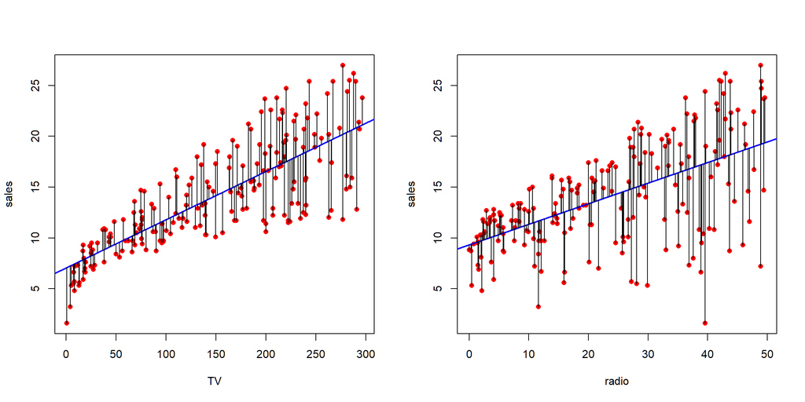

# Multiple Linear Regression Advertising Example

[interactive chart not shown]

# Multiple Linear Regression Advertising Example

The coefficients for a model for `sales` with `TV`, `radio` and `newspaper` look like this:

Fitting linear model: sales ~ TV + radio + newspaper

|  | Estimate | Std. Error | t value | Pr(>\|t\|) |
| --- | --- | --- | --- | --- |
| **(Intercept)** | 2.939 | 0.3119 | 9.422 | 1.267e-17 |
| **TV** | 0.04576 | 0.001395 | 32.81 | 1.51e-81 |
| **radio** | 0.1885 | 0.008611 | 21.89 | 1.505e-54 |
| **newspaper** | -0.001037 | 0.005871 | -0.1767 | 0.8599 |

`newspaper` seems no longer to have an effect on `sales`. The correlation between `newspaper` and `radio` is $0.35$.

|  | TV | radio | newspaper | sales |
| --- | --- | --- | --- | --- |
| **TV** | 1 | 0.05481 | 0.05665 | 0.7822 |
| **radio** |  | 1 | 0.3541 | 0.5762 |
| **newspaper** |  |  | 1 | 0.2283 |
| **sales** |  |  |  | 1 |

# Some Important Questions

1. Is at least one of the predictors useful in predicting the response?
2. Do all the predictors help explain $Y$, or is only a subset of the predictors useful?
3. How well does the model fit the data?
4. Given a set of predictor values, what response value should we predict, and how accurate is our prediction?

# 1. Is there a Relationship Between the Repsone and Predictors?

$$\begin{aligned}
H_0 :& \qquad \beta_1=\beta_2=\cdots=\beta_p=0\\
H_A :& \qquad \text{At least one $\beta_j$ is non-zero}
\end{aligned}$$

Use the $F$-statistic:

$$F=\frac{(\text(TSS)-\text{RSS})/p}{\text{RSS}/(n-p-1)} \quad \sim F_{p,n-p-1}$$

- avoids multiple tests for each predictor
- If subset of predictors is taken for granted, the $F$-statistic can also be uesd to test whether additional parameters are useful.

# 2. Do we need all predictors?

- First we need am method to judge the quality of models
  - $F$-test, AIC, BIC, adjusted $R^2$, …
  - all methods have in common that they introduce some ‘penalty’ for the number of predictors
- Then, we need a procedure to models of different subsets of predictors
  - compare all subsets
  - forward selection
  - backward selection
  - mixed forward&backward selection

# 3. How well does the model fit the data?

Most common are RSE and $R^2$, which we’ve seen for simple linear regression

## $R^2$

| TV: $0.612$ | Radio: $0.332$ | Newspaper: $0.052$ |
| --- | --- | --- |
| TV&Radio: $0.897$ | Radio&Newspaper: $0.333$ | TV&Newspaper: $0.646$ |
|  | TV&Radio&Newspaper: $0.897$ |  |

## RSE

| TV: $3.259$ | Radio: $4.275$ | Newspaper: $5.092$ |
| --- | --- | --- |
| TV&Radio: $1.681$ | Radio&Newspaper: $4.284$ | TV&Newspaper: $3.121$ |
|  | TV&Radio&Newspaper: $1.686$ |  |

- Newspaper leads little or no change in $R^2$ and to higher *RSE* even.
- Note: Adding an additional predictor cannot decrease $R^2$ (by design).

# 4. How accurate are our predictions?

Given some values for $X$ we can make predictions for $Y$. If, for example, 100000 is spent on `TV` and 20000 is spent on `radio`,

$$\hat y = \hat\beta_0 + \hat\beta_1 x_1 + \hat\beta_2 x_2 =
\hat\beta_0 + \hat\beta_1 \mathtt{TV} + \hat\beta_2 \mathtt{radio} = 11.26$$

Confidence interval vs prediction interval

```
##        fit      lwr      upr
## 1 11.25647 7.929616 14.58332
```

```
##        fit      lwr      upr
## 1 11.25647 10.98525 11.52768
```

# Small Excursus: Matrix Notation and Hat Matrix

Linear model in matrix notation:

$$\underbrace{\left(\begin{smallmatrix} y_1 \\ \vdots \\ y_n \end{smallmatrix}\right)}_{=:Y} =
\underbrace{\left(\begin{smallmatrix}
1 & x_{11} & \ldots & x_{1p} \\
\vdots & \vdots & & \vdots \\
1 & x_{n1} & \ldots & x_{np}
\end{smallmatrix}\right)}_{=:X} \cdot
\underbrace{\left(\begin{smallmatrix}
\beta_0 \\ \vdots \\ \beta_p
\end{smallmatrix}\right)}_{=:\beta} +
\underbrace{\left(\begin{smallmatrix}
\eps_1 \\ \vdots \\ \eps_n
\end{smallmatrix}\right)}_{\stackrel{i.i.d.}\sim \,\,\, N(0,\sigma^2)}$$

$X$ is called *design matrix*. The least squares estimator for the coefficients can then be expressed as

$$\hat \beta = \underbrace{(X^T X)^{-1}X^T }_{\small{\text{ Pseudoinverse of }} X} \cdot Y$$

The predictions for $Y$ based on $X$ are then

$$\hat Y = X\hat \beta = X (X^T X)^{-1}X^T \cdot Y := H \cdot Y$$

where $H$ is called *prediction* or *hat matrix*. $H$ contains a lot of useful information, most importantly: The values on the main diagonal are the **leverages** of each observation.